# Regresión logística: tópicos finales

# Efectos marginales

Debido a la naturaleza no lineal del modelo, no es posible interpretar los coeficientes directamente como en el modelo lineal, dado que el efecto marginal de la variable $x_i$ sobre la variable dependiente $y$, $(E(y|x))$ deja de ser una constante $(\beta_i)$ y pasa a ser dicha constante multiplicada por un factor de escala no trivial. Desarrollamos brevemente esta situación a continuación.

En un modelo lineal la probabilidad condicionada a las características viene dada por:

$$P(y=1|\mathbf{x})=\beta_0+\beta_1
x_1+\ldots+\beta_n x_n=\mathbf{x\beta}$$
donde es una matriz de tamaño $n\times k$, y $\beta$ un vector de tamaño $k\times 1$

Mientras que en la regresión logística

$$P(y=1|\mathbf{x})=G(\beta_0+\beta_1
x_1+\ldots+\beta_n x_n)=G(\mathbf{x\beta})$$

Como se observa la combinación lineal de regresores o características $(\mathbf{x\beta})$ afecta a la variable dependiente a través la función link $G()$, que en nuestro caso es la función logística. En el caso de la regresión lineal la función link es la función identidad, de ahí que los $\beta$’s se interpreten directamente como el efecto de un cambio en $x_i$ sobre $y$

Si deseamos obtener los efectos parciales o marginales en la regresión lineal, simplemente calculamos $\frac{\partial{y}}{\partial{x_i}}=\beta_i$

Mientras que en la regresión logística
$$\frac{\partial{y}}{\partial{x_i}}=\frac{\partial{G(\mathbf{x\beta})}}{\partial{x_i}}\beta_i=g(\mathbf{x\beta})\beta_i$$
donde $G()$ es la función de distribución acumulada y $g()$ la función de densidad.

Para calcular el efecto marginal debemos conocer no solo $\beta_i$ sino $\mathbf{x\beta}$ evaluado en $g()$

El cálculo de los efectos marginales plantea el problema de que $x$’s emplear en el cálculo de la expresión anterior. Se puede optar por el empleo del *efecto marginal promedio*, que citando el texto de Nick Huntington-Klein [The Effect](https://theeffectbook.net/ch-StatisticalAdjustment.html#getting-fancier-with-regression) consiste en *“El efecto marginal medio calcula el efecto marginal de cada observación individual, utilizando los predictores de esa observación. Luego, con el efecto marginal de cada observación individual, se obtiene la media para obtener el efecto marginal medio. !Eso es todo¡. Entonces se tiene la media del efecto marginal en toda la muestra, lo que da una idea del efecto marginal representativo”*. Usaremos esto en detrimento del efecto marginal *en el promedio*, el cual implicaría sustituir los $x$ por sus valores promedios.

El efecto marginal promedio se calcula del siguiente modo

$$\frac{1}{n}\sum_{i=1}^n
g(\mathbf{x_i\hat{\beta}})=\mathbf{\hat{\beta}}g(\overline{\mathbf{x\hat{\beta}}})$$
La expresión anterior no es más que la media de la combinación lineal con la estimación de $\beta$, evaluado en la función logística.

Vamos a usar el ejemplo del libro, en la implementación abajo mostrada queda más clara esta idea.

Estimamos primero el modelo del libro

```r
modelo_cap11_06 <- glm(data = HMDA, deny2 ~ pirat + afam, family = binomial(link = logit))
summ(modelo_cap11_06, digits = 3, robust = "HC1")
```

| Observations | 2380 |
| --- | --- |
| Dependent variable | deny2 |
| Type | Generalized linear model |
| Family | binomial |
| Link | logit |

| χ²(2) | 152.780 |
| --- | --- |
| Pseudo-R² (Cragg-Uhler) | 0.120 |
| Pseudo-R² (McFadden) | 0.088 |
| AIC | 1597.390 |
| BIC | 1614.715 |

|  | Est. | S.E. | z val. | p |
| --- | --- | --- | --- | --- |
| (Intercept) | -4.126 | 0.346 | -11.924 | 0.000 |
| pirat | 5.370 | 0.964 | 5.572 | 0.000 |
| afamyes | 1.273 | 0.146 | 8.708 | 0.000 |

Standard errors: Robust, type = HC1

A contonuación calculamos los efectos marginales “a mano”

```r
fav <- mean(dlogis(predict(modelo_cap11_06)))
efectos.marginales <- fav*modelo_cap11_06$coefficients
efectos.marginales
```

```
## (Intercept)       pirat     afamyes
##  -0.3981453   0.5182777   0.1228324
```

```r
efectos.marginales[2]
```

```
##     pirat
## 0.5182777
```

```r
efectos.marginales[3]
```

```
##   afamyes
## 0.1228324
```

En lugar de calcular manualmente los efectos marginales, el paquete `mfx` a través de su función `logitmfx` nos da el logit estimado y en lugar de presentar los $\beta$’s nos muestra directamente los efectos marginales. Como deseamos el *efecto marginal promedio*, debemos usar el argumento `atmean` y asignarle el valor `FALSE`, indicando que no deseamos el efecto marginal *en el promedio*.

```r
modelo_cap11_06_marg <- logitmfx(data = HMDA, deny2 ~ pirat + afam, atmean = FALSE, robust = TRUE)
modelo_cap11_06_marg
```

```
## Call:
## logitmfx(formula = deny2 ~ pirat + afam, data = HMDA, atmean = FALSE,
##     robust = TRUE)
##
## Marginal Effects:
##            dF/dx Std. Err.      z     P>|z|
## pirat   0.518278  0.101439 5.1093 3.234e-07 ***
## afamyes 0.166402  0.023999 6.9338 4.096e-12 ***
## ---
## Signif. codes:  0 '***' 0.001 '**' 0.01 '*' 0.05 '.' 0.1 ' ' 1
##
## dF/dx is for discrete change for the following variables:
##
## [1] "afamyes"
```

Observamos que el proceso manual no captura bien el efecto marginal de la variable categórica afroamericano.

Según estos resultados, un incremento de una unidad del ratio pagos sobre ingreso incrementa la probabilidad de no obtener el crédito en un 52%, mientras que el ser afroamericano aumenta la probabilidad de no recibir el crédito en un 17%.

# Probabilidades relativas

Una manera más sencilla de interpretar los coeficientes es calculando la exponencial de los mismos. Recordemos que estamos estimando la siguiente relación:

$$P(valoracion = 1 | \mathbf{x} ) =
\frac{1}{1+ e^{-\mathbf{x\beta}}}$$
Escribiendo el denominador de la expresión como:

$$1+\frac{1}{e^\mathbf{x\beta}}$$
podemos escribir la probabilidad condicionada de una valoración alta como:

$$\begin{align}
P(valoracion = 1 | \mathbf{x} ) = &
\frac{1}{1+\frac{1}{e^\mathbf{x\beta}}} \\
= &
\frac{1}{\frac{1+e^\mathbf{x\beta}}{e^\mathbf{x\beta}}}\\
= &
\frac{e^\mathbf{x\beta}}{1+e^\mathbf{x\beta}}
\end{align}$$

por lo que la probabilidad condicionada de una valoración baja sería:

$$\begin{align}
P(valoracion = 0 | \mathbf{x} ) = & 1-
\frac{e^\mathbf{x\beta}}{1+e^\mathbf{x\beta}} \\
= & \frac{1}{1+e^\mathbf{x\beta}}
\end{align}$$

Con lo anterior obtenemos el ratio de probabilidades

$$\begin{align}
\frac{P(valoracion = 1 | \mathbf{x} )}{P(valoracion = 0 | \mathbf{x} )}
= &
\frac{\frac{e^\mathbf{x\beta}}{1+e^\mathbf{x\beta}}}{\frac{1}{1+e^\mathbf{x\beta}}}
= & e^\mathbf{x\beta}
\end{align}$$

El exponencial de los coeficientes nos indican que tan más probable es en términos relativos que el crédito sea denegado cuando varía $x_i$ en una unidad manteniendo el restos de la $x$’s constante

```r
modelo_cap11_06_or <- exp(coef(modelo_cap11_06))
stargazer(modelo_cap11_06, type="text", coef=list(modelo_cap11_06_or), p.auto=FALSE)
```

```
##
## =============================================
##                       Dependent variable:
##                   ---------------------------
##                              deny2
## ---------------------------------------------
## pirat                     214.941***
##                             (0.728)
##
## afamyes                    3.571***
##                             (0.146)
##
## Constant                   0.016***
##                             (0.268)
##
## ---------------------------------------------
## Observations                 2,380
## Log Likelihood             -795.695
## Akaike Inf. Crit.          1,597.390
## =============================================
## Note:             *p<0.1; **p<0.05; ***p<0.01
```

Manteniendo el resto de variables constante, para una persona afroamericana es 3,57 veces más probable que el crédito sea denegado.

# Evaluación del modelo: Matriz de confusión y curva ROC

## Matriz de confusión

Ya hemos analizado la matriz de confusión en clase y alguna de las métricas de bondad de ajuste de el modelo que se pueden obtener de la misma. Ahora vamos a repetir el ejercicio de clase y obtendremos la matriz y las métricas a través de la librería `caret`

Dividimos la muestra, dejamos algunas observaciones fuera, para luego predecir con las características de estas observaciones. Determinamos de manera aleatoria que elementos sacamos de la muestra.

```r
set.seed(1234)
filas <- sample(x = rownames(HMDA),300)
filas
```

[output not shown]

Dividimos la muestra en dos

```r
HMDA_train <- HMDA[-as.numeric(filas),]
HMDA_test <- HMDA[as.numeric(filas),]
```

Estimamos con los datos restantes

```r
modelo_cap11_train <- glm(data = HMDA_train, deny2 ~ pirat + afam, family = binomial(link = logit))
summ(modelo_cap11_train, digits = 3, robust = "HC1")
```

| Observations | 2080 |
| --- | --- |
| Dependent variable | deny2 |
| Type | Generalized linear model |
| Family | binomial |
| Link | logit |

| χ²(2) | 143.826 |
| --- | --- |
| Pseudo-R² (Cragg-Uhler) | 0.130 |
| Pseudo-R² (McFadden) | 0.095 |
| AIC | 1370.155 |
| BIC | 1387.075 |

|  | Est. | S.E. | z val. | p |
| --- | --- | --- | --- | --- |
| (Intercept) | -4.245 | 0.382 | -11.105 | 0.000 |
| pirat | 5.605 | 1.067 | 5.255 | 0.000 |
| afamyes | 1.354 | 0.158 | 8.586 | 0.000 |

Standard errors: Robust, type = HC1

Predecimos los valores de las observaciones que hemos dejado fuera

```r
prediccion <-  predict(object = modelo_cap11_train, newdata = HMDA_test, type = "response")
prediccion
```

[output not shown]

[output cut: 31 more lines]

```
## 0.28307904 0.06443415 0.04445295 0.03395747 0.23986195 0.06443415 0.06789655
##       1024         41       2270       1600        772       1944       1119
## 0.26089191 0.10237917 0.06309576 0.08792707 0.08353474 0.11889702 0.08792707
##       2335        731        746        755       1003       2244       2101
## 0.31840929 0.07138203 0.13767113 0.07153079 0.23986195 0.25022977 0.10588208
##        875       2102       1659       1407       2122        191        694
## 0.07772041 0.08837759 0.26089191 0.06932924 0.07573523 0.13767113 0.02885348
##       1963       1690       1284       1503         34       2155        166
## 0.31840929 0.29459092 0.07153079 0.09734195 0.10237917 0.09685058 0.05986245
##       2012       1630       2007        936        350       1868       2272
## 0.06684010 0.04689548 0.04664559 0.34448100 0.01413470 0.09734195 0.08452697
##       1055        547        491       1677         11       1173       2020
## 0.07153079 0.04946526 0.11889702 0.11889702 0.06443415 0.06789655 0.07573523
##       1381         19        730       1831        784        235
## 0.03395747 0.07534382 0.03682617 0.31840929 0.22002254 0.07153079
```

Convertimos las probabilidades en variables binarias, asumimos que una probabilidad estimada mayor a 0,5 indica que se deniega el crédito a esa persona

```r
prediccion_deny <- ifelse(prediccion > 0.5, 1, 0)
prediccion_deny
```

```
## 1004  623  934  400 2146 1626 2374 1103  270 2232 2052 1685 1236 1219  996  479
##    0    0    0    0    0    0    0    0    0    0    1    0    0    0    0    0
##  634  901  578 1403 1132  131 1014  740 1952  298 1835  258   79  307  902 1245
##    0    0    0    0    0    0    0    0    0    0    0    0    0    0    0    0
##  561  136 1169  959 2171 1800 1258  608  495  534 2256 1155  569 1546  951 2296
##    0    0    0    0    0    0    0    0    0    0    0    0    0    0    0    0
## 1389 1667  595  434  760 1751 2324  169 1983 1095  573  864 1971  326 1691  840
##    0    0    0    0    0    0    0    0    0    1    0    0    0    0    0    0
## 2108  548 1911  319 2193  102  214  390 1621  597  160 1986 2174  442  181  779
##    0    0    0    0    0    0    0    0    0    0    0    0    0    0    0    0
##  163  228  938 2311 1289   40  877 1474  806  670  838  478 1427 1399 2037  598
##    0    0    0    0    0    0    0    0    0    0    0    0    0    0    0    0
## 2119  891 1212 1456 1915  488  912  215  540  613 2281  931 1859  328 1171 1725
##    0    0    0    0    0    0    0    0    0    0    0    0    0    0    0    0
## 1912 1108  250 1991  529  281  898  869 2058 2339 1465 2348 1616  585  293  303
```

[output cut: 23 more lines]

Obtenemos la matriz de confusión

```r
table(HMDA_test$deny2)
```

```
##
##   0   1
## 260  40
```

```r
table(prediccion_deny, HMDA_test$deny2)
```

```
##
## prediccion_deny   0   1
##               0 260  37
##               1   0   3
```

La precisión (ACC) es del 87,7% (aciertos sobre el total 263/300), la tasa de acierto de las concesiones de crédito es del 100% y las no concesiones del 7,5% (3/40)

Vamos a obtener esta información con la función `confusionMatrix` de la librería `caret`, pero antes debemos realizar unos pequeños cambios

La función `confusionMatrix` asume que la variable dependiente (respuesta) es un factor, así como la predicción. Esto implica que debemos usar la columna original de la base de datos `HMDA` que se encuentra codificada con una variable binaria `yes` y `no`, y cambiar la variable que hemos usado para construir la matriz anterior y convertirla en factor:

```r
prediccion_deny2 <- ifelse(prediccion > 0.5, "yes", "no")
prediccion_deny2 <- as.factor(x = prediccion_deny2)
```

Ahora pasamos a construir la matriz

```r
confusionMatrix(prediccion_deny2, HMDA_test$deny, positive = "yes")
```

```
## Confusion Matrix and Statistics
##
##           Reference
## Prediction  no yes
##        no  260  37
##        yes   0   3
##
##                Accuracy : 0.8767
##                  95% CI : (0.834, 0.9117)
##     No Information Rate : 0.8667
##     P-Value [Acc > NIR] : 0.3419
##
##                   Kappa : 0.1232
##
##  Mcnemar's Test P-Value : 3.252e-09
##
##             Sensitivity : 0.0750
##             Specificity : 1.0000
##          Pos Pred Value : 1.0000
##          Neg Pred Value : 0.8754
##              Prevalence : 0.1333
##          Detection Rate : 0.0100
##    Detection Prevalence : 0.0100
##       Balanced Accuracy : 0.5375
##
##        'Positive' Class : yes
##
```

Vemos como obtenemos la misma información de antes además de otras métricas

El tomar 0,5 como límite para determinar la probabilidad de una valoración alta es una decisión estándar pero arbitraria. Existen maneras de determinar si esta tasa es la adecuada empleando varios criterios, a continuación mostramos como varía la precisión del modelo con distintos limites.

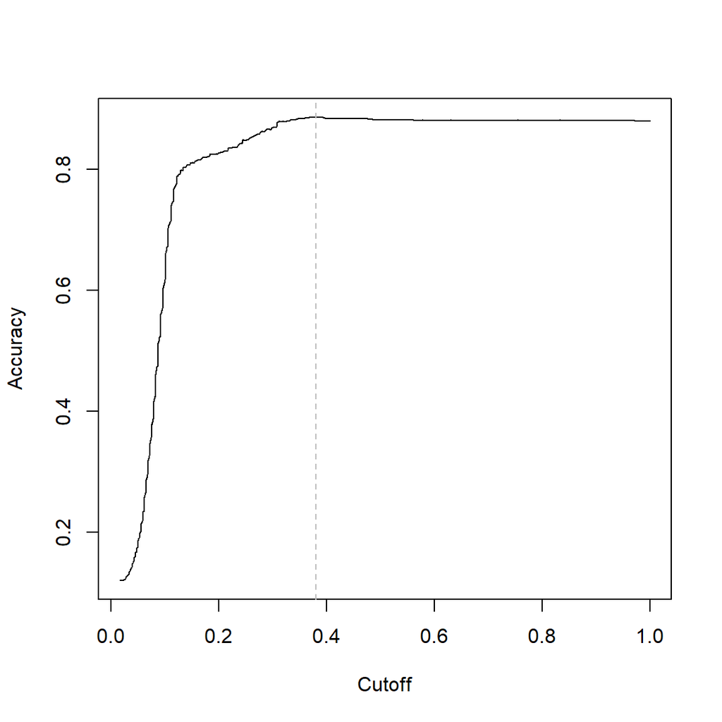

```r
prediccion_th <- prediction(fitted(modelo_cap11_06), HMDA$deny)
precision <- performance(prediccion_th,'acc')
ac.val = max(unlist(precision@y.values))
th = unlist(precision@x.values)[unlist(precision@y.values) == ac.val]
plot(precision)
abline(v=th, col='grey', lty=2)
```

```r
unname(th)
```

```
## [1] 0.3799368
```

En la gráfica anterior se representa en el eje vertical la precisión (ACC) del modelo y en el eje horizontal la *probabilidad de corte* a partir de la cual definimos cuando se considera que se deniega un crédito. El objetivo es buscar una probabilidad de corte que maximice la precisión del modelo, dicho valor no tiene porque ser único.

En la gráfica se observa que el límite que maximiza la precisión es 0.38 que viene dado por la variable `th`. La precisión (ACC) del modelo es ahora 0.89 Repetimos la elaboración de la matriz de confusión con ese límite

```r
prediccion_deny3 <- ifelse(prediccion > unname(th), "yes", "no")
prediccion_deny3 <- as.factor(x = prediccion_deny3)
```

Ahora pasamos a construir la matriz

```r
confusionMatrix(prediccion_deny3, HMDA_test$deny, positive = "yes")
```

```
## Confusion Matrix and Statistics
##
##           Reference
## Prediction  no yes
##        no  257  36
##        yes   3   4
##
##                Accuracy : 0.87
##                  95% CI : (0.8266, 0.9059)
##     No Information Rate : 0.8667
##     P-Value [Acc > NIR] : 0.4744
##
##                   Kappa : 0.1359
##
##  Mcnemar's Test P-Value : 2.99e-07
##
##             Sensitivity : 0.10000
##             Specificity : 0.98846
##          Pos Pred Value : 0.57143
##          Neg Pred Value : 0.87713
##              Prevalence : 0.13333
##          Detection Rate : 0.01333
##    Detection Prevalence : 0.02333
##       Balanced Accuracy : 0.54423
##
##        'Positive' Class : yes
##
```

## Curva ROC

A continuación se muestra la curva ROC

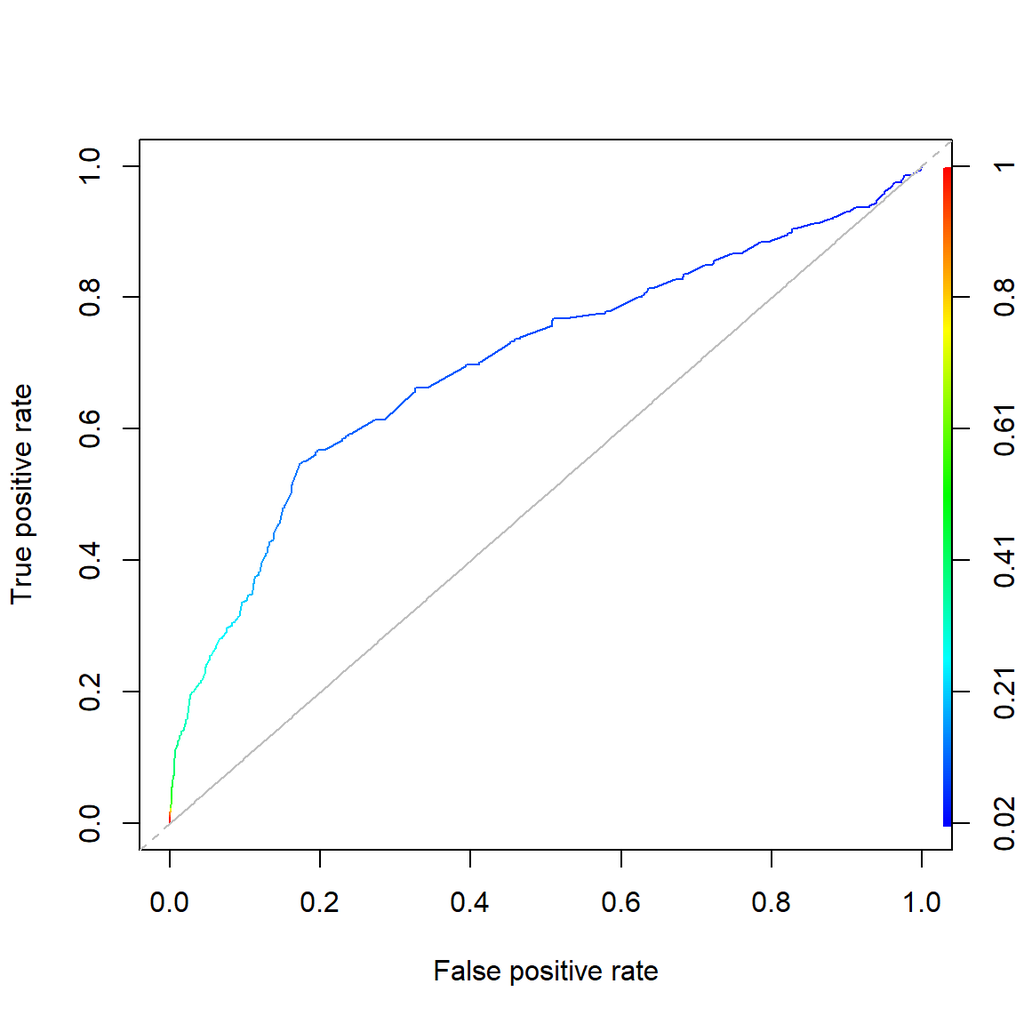

```r
plot(performance(prediccion_th,'tpr','fpr'),colorize=T)
abline(0,1,lty=2, col='grey')
lines(x=c(0, 1), y=c(0, 1), col="grey", lty=2)
```

Calculamos el AUC o área bajo la curva ROC

```r
auc = performance(prediccion_th, "auc")
auc = unlist(auc@y.values)
auc
```

```
## [1] 0.7013432
```

Se obtiene un AUC de 0.7, que es mayor al límite de 0,5 que representa una clasificación hecha al azar, pero la forma de la curva ROC, nos indica que el modelo tiene margen de mejora. Recordar que una curva ROC lo más pegada al eje vertical y al eje superior, y un AUC cercano a uno, indican una mejor clasificación.